# CSE 512 Homework 2

## Dataset: Yelp Dataset

This Yelp dataset consists of large amount of data from 6 aspects (business, checkin, photos, review, user, and tip). In this analysis report, we'd like to investigate the data in Washington state.

## Analysis Questions

1. How are businesses with different stars distributed in cities in WA?
2. What's the relationship between writing a review and its star?
3. What are the trends of review for different business types?
4. Does becoming a Elite member make a user write more reviews?

### 0. How are businesses with different stars distributed in cities in WA?

#### Sanity checks

Before we further analyze the business data in Washington state, we need to check the data quality. After extracting datapoints with `'state'=='WA'`, we find that there're 3121 datapoints with listed cities `'North Vancouver', 'Vancover', 'Felida', 'Vancouver', 'Castle Rock', 'Vanvouver', 'Camas', 'Orchards', 'Everett', 'Portland', 'Ridgefield', 'Beaverton', 'Homan', 'VANCOUVER', 'Hazel Dell'`. Since North Vancouver belongs to Canada and Beaverton and Portland are in Oregon state, here we exclude these datapoints with these three cities. We also combine datapoints with city `'Vancover', 'Vancouver', 'Vanvouver', and 'VANCOUVER'` into `'Vancouver'`, as we believe these are typos or case negligence. After this revision, we get 3115 business datapoints in WA. Now let's visulize it!

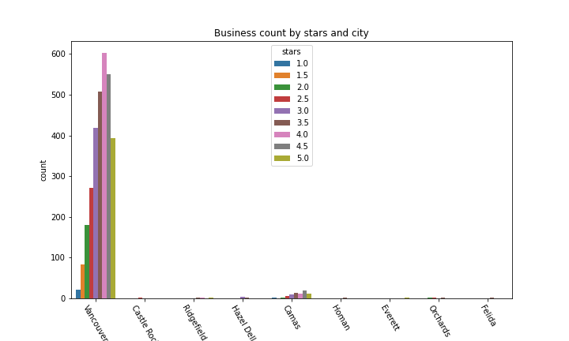

Before this plotting, we didn't expect that the business data in WA is so incomplete. This Yelp dataset might have done some data filtering or other processing so that an overwhelming majority of businesses are located in Vancouver and it's impossible to grasp a sense of distribution as one can tell the data is not fair by one glance. Hence, we're not going to do further analysis in the aspect of businesses distribution. We'll keep on users and reviews data.

### 1. What's the relationship between writing a review and its star?

This question naturally comes up to my mind when I am thinking: What makes a customer want to write a review? Is it because it's super good that one would like to advertise it? Or is it because it's too bad that one wants to complain? Or people are willing to write reviews any time? Driven by this thought, we're going to explore the review data to see if there's a relationship.

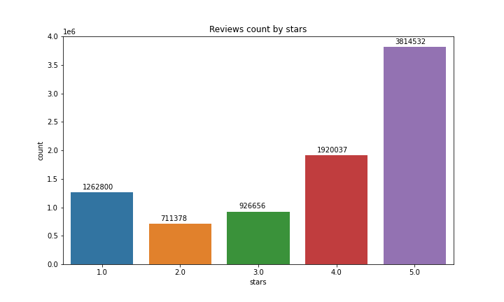

Assume the dataset is not collected biasedly in the aspect of reviews, it seems that people tend to write a review when they think the business is good (4&5 star) or bad (1 star).

Not all the reviews takes the same time. Maybe leaving a long review will show people's willingness more strongly. Hence we'd like to further investigate the text people leave.

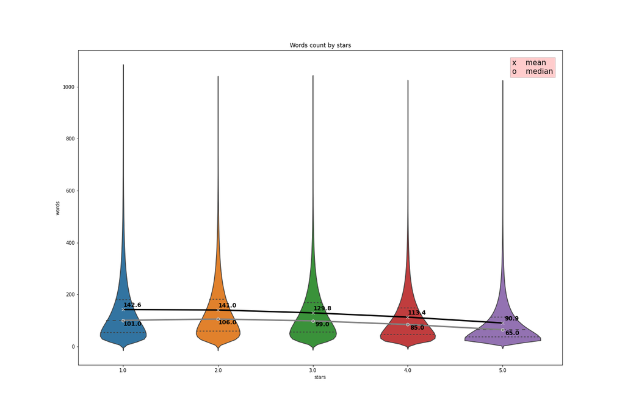

Although people tend to leave review for very good (4&5 stars) and very bad (1 star) business, this plot shows that people like to leave longer review when they give less stars. Do people tend to say more in a complaint rather than a compliment? (I have no idea but it's definitely interesting to me!)

### 2. What are the trends of review for different business types?

After grouping businesses by categories, we get 1330 categories.

For brevity and clearness, we first show the top 15 reviewed business categories.

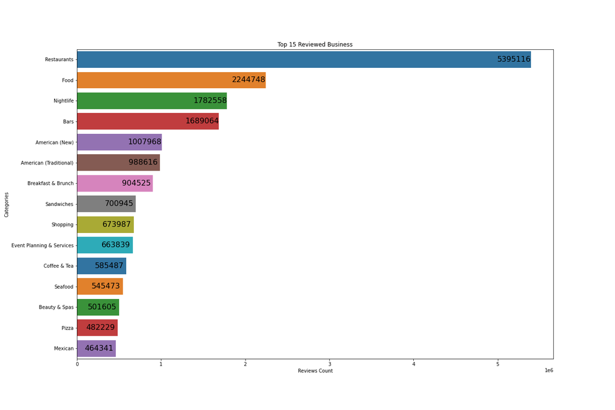

The most reviewed business is Restaurant. However, we can easily see that there're many sub-categories of restaurants in this chart.

Now we'd like to see the trends of different types of business getting reviews. We'll first exclude the categories "Restaurants" and "Food" as they are too general. Now we have 13 categories, and we're going to use the review dataset to see how many reviews each category received in each recent years.

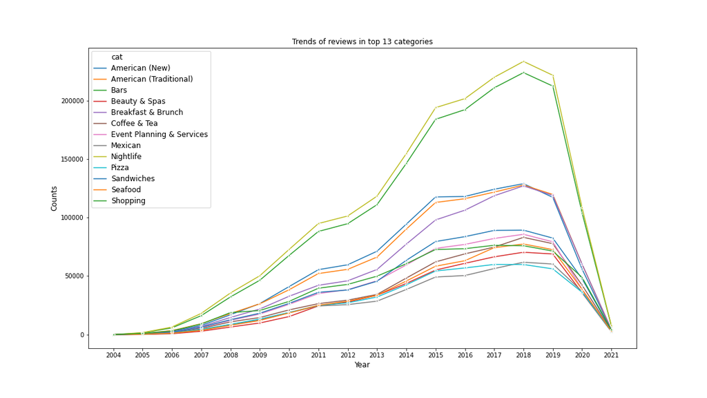

Is there any business who get more reviews in 2020?

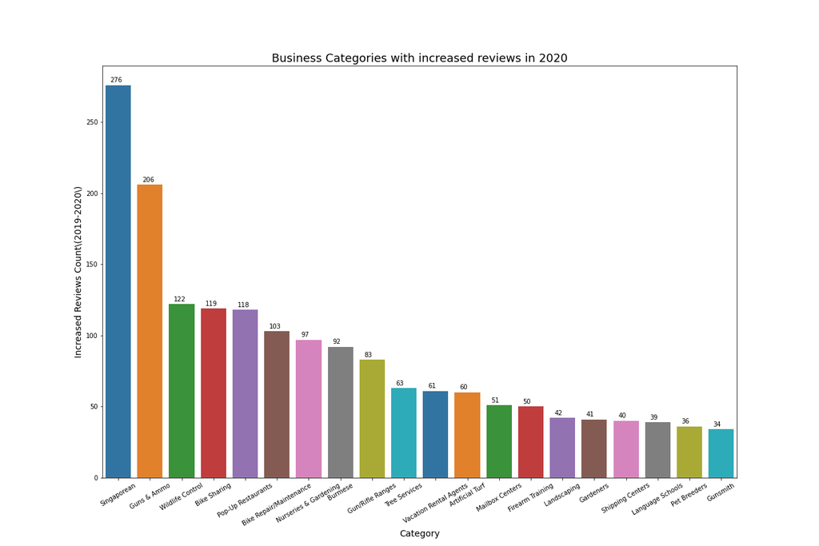

### 3. Does becoming a Elite member make a user write more reviews?

We use the yelp user dataset and group the users by whether they're once a elite member. And when we plot the counts of reviews they write...

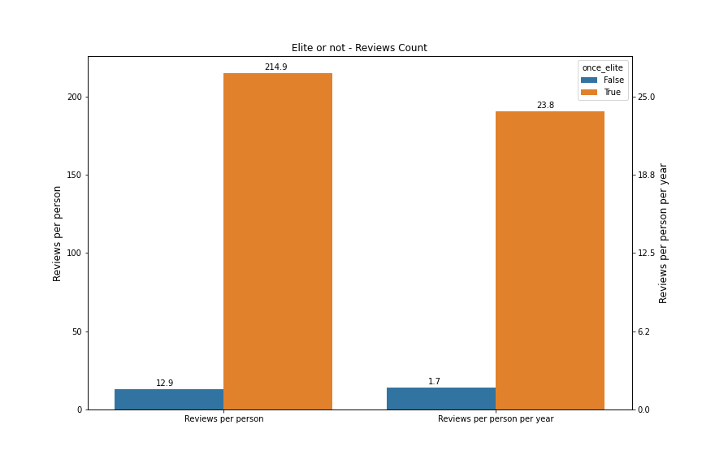

The answer is a big YES! We calculate the average number of reviews written by per person and their annual average number of reviews. And the gap is tremendous -- elite users write about 14x reviews than non-elite users!

Can we look for users who were once elite members and quit afterwards and see if the same pattern holds? We filtered out the users who have never been elite members and find the elite users' reviews in the review dataset. Grouping by the year they're elite users or non-elite users, we get the reviews count result.

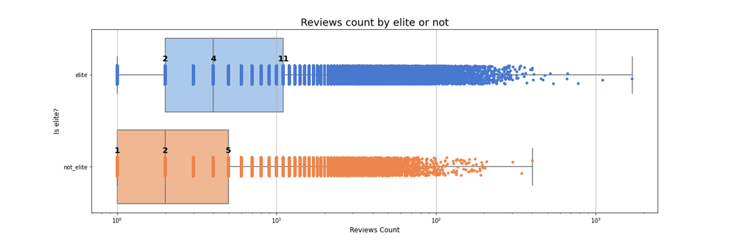

Another big difference shows! The focused once-an-elite-member users are the ones who write more reviews as we analyze above. However, these people also write less amount of reviews when they're not elite users (quit or haven't join). Maybe an "Elite" title makes people more willing to write reviews as they'll have more impact in the yelp community!